# Renny_Oyelahan_Project_01

**Importing Necessary Libraries**

```python
from google.colab import drive
drive.mount('/content/drive')
```

```python
# Libraries to help with reading and manipulating data
import numpy as np
import pandas as pd

# Libraries to help with data visualization
import matplotlib.pyplot as plt
import seaborn as sns

# Command to tell Python to actually display the graphs
%matplotlib inline
```

**Importing the Dataset**

```python
path = '/content/drive/MyDrive/Colab_Notebooks/CardioGoodFitness.csv'
data = pd.read_csv(path)
```

**View the first and last 5 rows of the Dataset**

```python
data.head()
```

|  | Product | Age | Gender | Education | MaritalStatus | Usage | Fitness | Income | Miles |
| --- | --- | --- | --- | --- | --- | --- | --- | --- | --- |
| 0 | TM195 | 18 | Male | 14 | Single | 3 | 4 | 29562 | 112 |
| 1 | TM195 | 19 | Male | 15 | Single | 2 | 3 | 31836 | 75 |
| 2 | TM195 | 19 | Female | 14 | Partnered | 4 | 3 | 30699 | 66 |
| 3 | TM195 | 19 | Male | 12 | Single | 3 | 3 | 32973 | 85 |
| 4 | TM195 | 20 | Male | 13 | Partnered | 4 | 2 | 35247 | 47 |

```python
data.tail()
```

|  | Product | Age | Gender | Education | MaritalStatus | Usage | Fitness | Income | Miles |
| --- | --- | --- | --- | --- | --- | --- | --- | --- | --- |
| 175 | TM798 | 40 | Male | 21 | Single | 6 | 5 | 83416 | 200 |
| 176 | TM798 | 42 | Male | 18 | Single | 5 | 4 | 89641 | 200 |
| 177 | TM798 | 45 | Male | 16 | Single | 5 | 5 | 90886 | 160 |
| 178 | TM798 | 47 | Male | 18 | Partnered | 4 | 5 | 104581 | 120 |
| 179 | TM798 | 48 | Male | 18 | Partnered | 4 | 5 | 95508 | 180 |

**Checking the shape of the Dataset**

```python
data.shape
```

```
(180, 9)
```

There are 180 rows and 9 columns in this Dataset

**Checking the data types of the columns in the Dataset**

```python
data.info()
```

```
<class 'pandas.core.frame.DataFrame'>
RangeIndex: 180 entries, 0 to 179
Data columns (total 9 columns):
 #   Column         Non-Null Count  Dtype
---  ------         --------------  -----
 0   Product        180 non-null    object
 1   Age            180 non-null    int64
 2   Gender         180 non-null    object
 3   Education      180 non-null    int64
 4   MaritalStatus  180 non-null    object
 5   Usage          180 non-null    int64
 6   Fitness        180 non-null    int64
 7   Income         180 non-null    int64
 8   Miles          180 non-null    int64
dtypes: int64(6), object(3)
memory usage: 12.8+ KB
```

- There are 6 numerical columns in the data and 3 object type columns.
- We observe that all columns have 180 entries, which is equal to the number of rows which indicates there are no missing values in this Dataset.

**Let's double-check for null values in the Dataset**

```python
data.isnull().sum()
```

```
Product          0
Age              0
Gender           0
Education        0
MaritalStatus    0
Usage            0
Fitness          0
Income           0
Miles            0
dtype: int64
```

There are no missing values in 9 columns of the DataSet which confirms our earlier observation.

**Checking for duplicate entries in the Dataset**

```python
data.duplicated().sum()
```

```
0
```

There are no duplicate entries in the Dataset

**Checking the statistical summary of the Dataset**

```python
data.describe().T
```

|  | count | mean | std | min | 25% | 50% | 75% | max |
| --- | --- | --- | --- | --- | --- | --- | --- | --- |
| Age | 180.0 | 28.788889 | 6.943498 | 18.0 | 24.00 | 26.0 | 33.00 | 50.0 |
| Education | 180.0 | 15.572222 | 1.617055 | 12.0 | 14.00 | 16.0 | 16.00 | 21.0 |
| Usage | 180.0 | 3.455556 | 1.084797 | 2.0 | 3.00 | 3.0 | 4.00 | 7.0 |
| Fitness | 180.0 | 3.311111 | 0.958869 | 1.0 | 3.00 | 3.0 | 4.00 | 5.0 |
| Income | 180.0 | 53719.577778 | 16506.684226 | 29562.0 | 44058.75 | 50596.5 | 58668.00 | 104581.0 |
| Miles | 180.0 | 103.194444 | 51.863605 | 21.0 | 66.00 | 94.0 | 114.75 | 360.0 |

```python
# let's check the total number of unique values in the Education column
data['Education'].nunique()
```

```
8
```

- There are a total of 8 different years spent in education in the data.

**Let's check the count and percentage of categorical levels in each column**

```python
# Making a list of all categorical variables
cat_cols =  ['Product', 'Gender', 'MaritalStatus']

# Printing the count of unique categorical levels in each column
for column in cat_cols:
    print(data[column].value_counts())
    print("-" * 50)
```

```
TM195    80
TM498    60
TM798    40
Name: Product, dtype: int64
--------------------------------------------------
Male      104
Female     76
Name: Gender, dtype: int64
--------------------------------------------------
Partnered    107
Single        73
Name: MaritalStatus, dtype: int64
--------------------------------------------------
```

```python
# Printing the percentage of unique categorical levels in each column
for column in cat_cols:
    print(data[column].value_counts(normalize=True))
    print("-" * 50)
```

```
TM195    0.444444
TM498    0.333333
TM798    0.222222
Name: Product, dtype: float64
--------------------------------------------------
Male      0.577778
Female    0.422222
Name: Gender, dtype: float64
--------------------------------------------------
Partnered    0.594444
Single       0.405556
Name: MaritalStatus, dtype: float64
--------------------------------------------------
```

**Observations**

- TM195 is the product number of the most commonly bought treadmill.
- 58 % of the customers are males, while 42 % of the customers are females.
- 60 % of the customers are partnered, while 40 % of the customers are single.

### Univariate Analysis

**Let's check the distribution for numerical columns.**

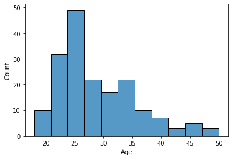

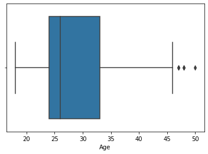

```python
# checking the age of the customers
sns.histplot(data=data, x="Age")
plt.show();
sns.boxplot(data=data, x="Age")
plt.show();
```

- The Age distribution is skewed to the right
- There are a few outliers observed after 46 years old indicating that there are few customers above 46 years old.

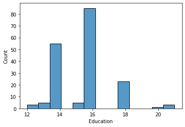

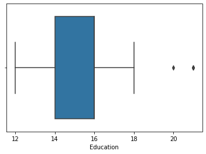

```python
# checking Eduaction (number of years) of the customers
sns.histplot(data=data, x="Education")
plt.show();
sns.boxplot(data=data, x="Education")
plt.show();
```

- The majority of the customers have between 12 to 18 years of education.

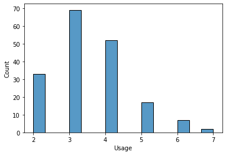

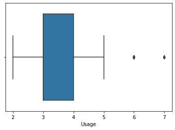

```python
# checking how many times per week (usage) customers use the treadmill
sns.histplot(data=data, x="Usage")
plt.show();
sns.boxplot(data=data, x="Usage")
plt.show();
```

- The majority of the customers use the treadmills between 2 to 5 times per week.

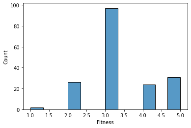

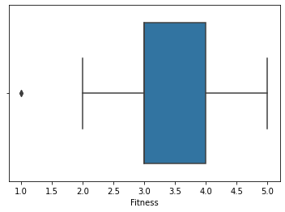

```python
# checking how many customers rate their own fitness
sns.histplot(data=data, x="Fitness")
plt.show();
sns.boxplot(data=data, x="Fitness")
plt.show();
```

- The majority of the customers rate their own fitness between 2 to 5.

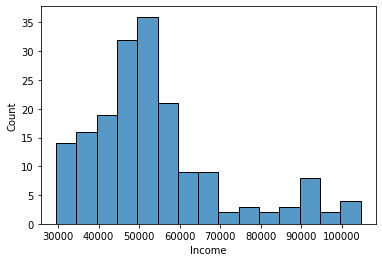

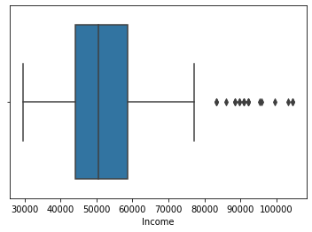

```python
# checking the income of the customers
sns.histplot(data=data, x="Income")
plt.show();
sns.boxplot(data=data, x="Income")
plt.show();
```

- The distribution is skewed to the right.
- There are several outliers after income of 79000

```python
# checking how many customers earn more than 79000
data.loc[data['Income']>79000].shape
```

```
(19, 9)
```

- There are 19 customers that earn more than 790000

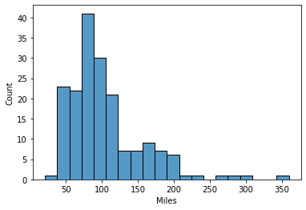

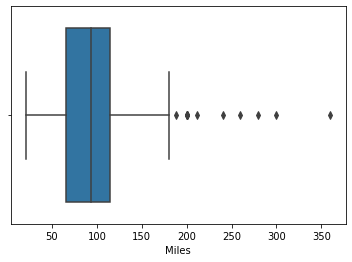

```python
# checking how many miles the customers expect to run
sns.histplot(data=data, x="Miles")
plt.show();
sns.boxplot(data=data, x="Miles")
plt.show();
```

- The distribution is skewed to the right.
- There are several outliers after 190 miles

```python
# checking how many customers run more than 190 miles
data.loc[data['Miles']>190].shape
```

```
(12, 9)
```

- There are 12 customers that run more than 190 miles

### Bivariate Analysis - Let's learn about the customers that use each product

**Observations on Age of customers that use each product**

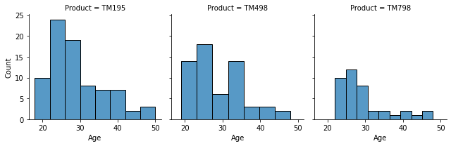

```python
g = sns.FacetGrid(data, col="Product")
g.map(sns.histplot, "Age");
```

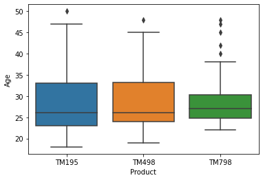

```python
sns.boxplot(data=data, x='Product', y='Age');
```

**Observations on Education of customers that use each product**

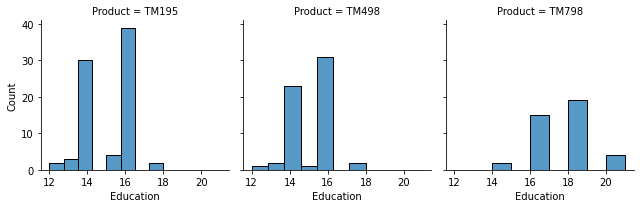

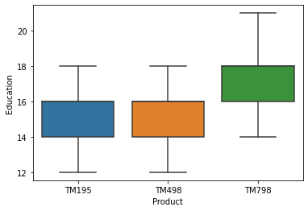

```python
g = sns.FacetGrid(data, col="Product")
g.map(sns.histplot, "Education")
plt.show()
sns.boxplot(data=data, x='Product', y='Education')
plt.show()
```

- The education distribution is slightly skewed towards the left.
- No outliers are shown in this column.
- It appears customers with the most years of education are more likely to buy TM798

**Observations on Usage of customers that use each product**

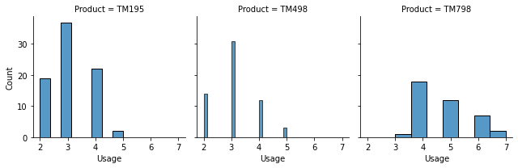

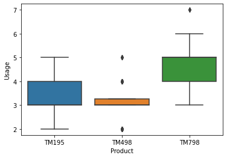

```python
g = sns.FacetGrid(data, col="Product")
g.map(sns.histplot, "Usage")
plt.show()
sns.boxplot(data=data, x='Product', y='Usage')
plt.show()
```

- The usage distribution is slightly skewed towards the right.
- Customers that buy TM798 are more likely to use their treadmill the most of all the customers.
- Customers that buy TM498 are more likely to use their treadmill about 3 days per week.

**Observations on Fitness of customers that use each product**

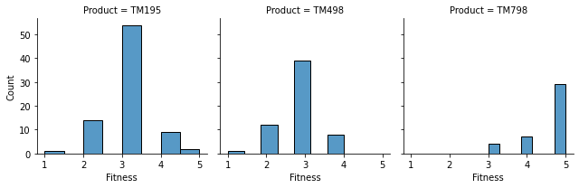

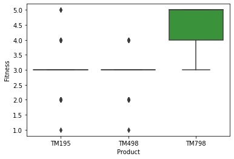

```python
g = sns.FacetGrid(data, col="Product")
g.map(sns.histplot, "Fitness")
plt.show()
sns.boxplot(data=data, x='Product', y='Fitness')
plt.show()
```

- For TM798, The fitness distribution is skewed towards the left, that indicates that customers who rate themselves between 3 to 5 fitness level are more likely to purchase TM798.
- For both TM195 and TM498, their fitness distribution are somewhat neutral, that is, not postively or negatively skewed. That indicates that most of their customers rate themselves 3 fitness level.

**Observations on Income of customers that use each product

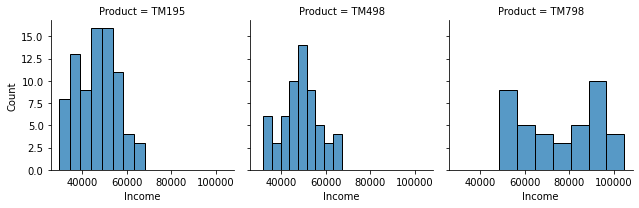

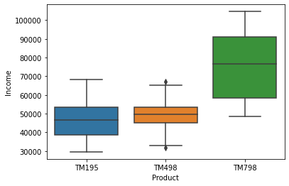

```python
g = sns.FacetGrid(data, col="Product")
g.map(sns.histplot, "Income")
plt.show()
sns.boxplot(data=data, x='Product', y='Income')
plt.show()
```

- The distribution of the both TM195 and TM498 are slightly skewed to the right.
- Customers that purchase TM798 are more likely to earn more money than those that purchase both TM195 and TM498.

**Observations on Miles ran by customers that use each product**

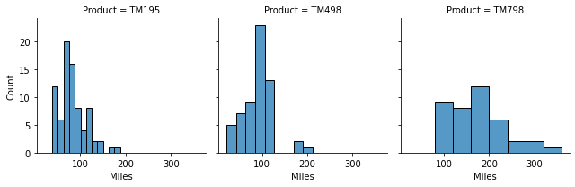

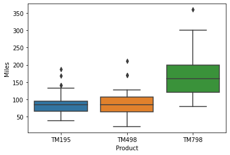

```python
g = sns.FacetGrid(data, col="Product")
g.map(sns.histplot, "Miles")
plt.show()
sns.boxplot(data=data, x='Product', y='Miles')
plt.show()
```

**Observations of gender of customers that use each product**

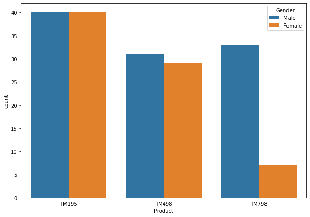

```python
plt.figure(figsize=(10,7))
sns.countplot(data=data, x='Product', hue='Gender');
```

- We observe that more males purchase TM798 than females.
- We also oberve that males and females purchase TM195 and TM498 at about the same rate.

**Observations of marital status of customers that use each product**

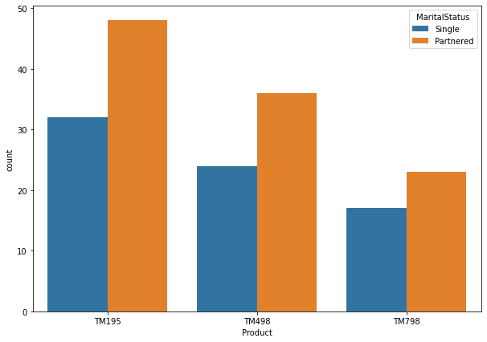

```python
plt.figure(figsize=(10,7))
sns.countplot(data=data, x='Product', hue='MaritalStatus');
```

- We observe that partnered customers purchase all 3 products, than single customers

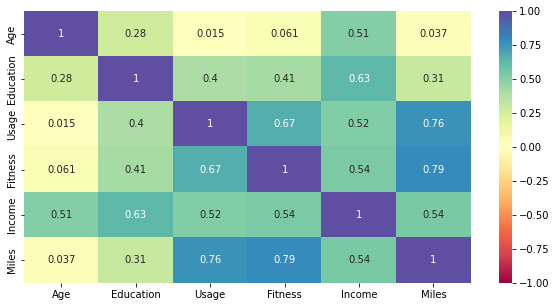

```python
plt.figure(figsize=(10,5))
sns.heatmap(data.corr(),annot=True,cmap='Spectral',vmin=-1,vmax=1)
plt.show()
```

**Observations**

**Let's dig deeper into the relationship between a few more variables using catplot**

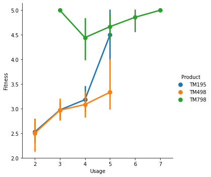

```python
sns.catplot(data=data, x='Usage', y='Fitness', hue='Product', kind='point');
```

We observe that the customers that purchased TM798 rate themselves highly when it comes to fitness and they use their treadmill the most.

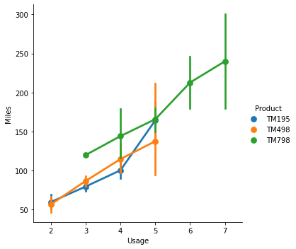

```python
sns.catplot(data=data, x='Usage', y='Miles', hue='Product', kind='point');
```

We observe that the customers that purchased TM798 use their treadmills the most.

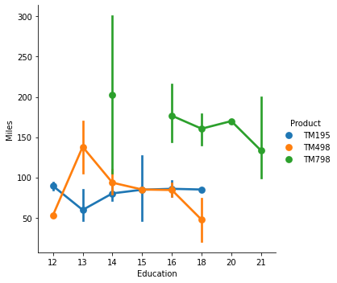

```python
sns.catplot(data=data, x='Education', y='Miles', hue='Product', kind='point');
```

We observe that the customers with the most years spent in education are more likely to buy TM798

**Observations**

**TM195 customer profile**:

- More customers, regardless of their age, tend to purchase TM195 than customers that purchase TM798.
- Tends to have between 12-18 years of education.
- Tends to use the treadmill between 2-5 days per week.
- On average, tends to rate their fitness level a 3.
- Tends to earn between 30000 and 69000.
- Tends to run an average of 90 miles per week.
- Males and females tend to purchase TM195 at the same rate.
- Of the Customers that purchase TM195, slightly more of them tend to be Partnered.
- Tends to be rate themselves as less fit then customers of TM798 and slightly more fit than customers of TM498.
- Tends to report a similar usage to customers of TM498 and less usage than customers of TM798.
- Tends to be about as educated as the customers of TM498 and less educated than customers of TM798.

**TM798 custome profile**:

- Of the different age groups, the least number of customers purchased TM798.
- Tends to have between 14 to 21 years of education.
- Tends to report using their treadmills between 3 to 7 times per week.
- Tends to rate their fitness level between 3 to 5.
- On average, they tend to earn about 79000, which is higher than the maximum earned by customers that purchased TM195 and TM498.
- Tend to run between 90 and about 320 miles per week, which is higher than those ran by customers that purchased TM195 and TM498.
- Of the customers that purchased TM798, there are more males than females.
- Of the customers that purchased TM798, there are more partnered than singles.
- Tend to report the highest fitness level and run the most miles per week.
- Tend to use their treadmill the most of the other customer profiles.

**Recommendations**

- Customers that purchase TM195 and TM498 share similar characteristics and companies should target customers regardless of their gender and marital staus that are between 19 to 50 years old and earn less than 70000. They also have at most 18 years of education, and are not extreme users of the treadmill
- For TM798 customers, companies should target males that are in a relationship that have the most years of education, that report they religously use their treadmill, and rate themselves as very fit, and on average earn more and run more miles than the customers that purchased TM195 and TM498